# Chapter6

Juho Ivaska, 9.12.2018

This final peace of course work is named chapter 6 because I thought it would be logical. We use the BPRS and RATS data from the previously done wrangling.

First, some packages maybe or maybe not needed in the future:

```r
library(data.table)
library(dplyr)
library(stringr)
```

```r
library(ggplot2)
library(GGally)
library(tidyr)
```

First we shall work with RATS data and do some plots. I had some troubles with knitting this file so I put all the wrangling done before here to make sure knitting goes well.

```r
BPRS <- read.table("https://raw.githubusercontent.com/KimmoVehkalahti/MABS/master/Examples/data/BPRS.txt", header = TRUE, sep = " ")
RATS <- read.table("https://raw.githubusercontent.com/KimmoVehkalahti/MABS/master/Examples/data/rats.txt", header = T, sep = "\t")

BPRS$treatment <- factor(BPRS$treatment)
BPRS$subject <- factor(BPRS$subject)

RATS$ID <- factor(RATS$ID)
RATS$Group <- factor(RATS$Group)

BPRSL <- BPRS %>%
  gather(week, BPRS, week0:week8)
RATSL <- RATS %>%
  gather(Time, Weight, WD1:WD64)
```

Here’s a plot which gives the change of rats’ weights through the study period of 9 weeks. In the study, three groups of rats were fed differently and scientists followed their weight.

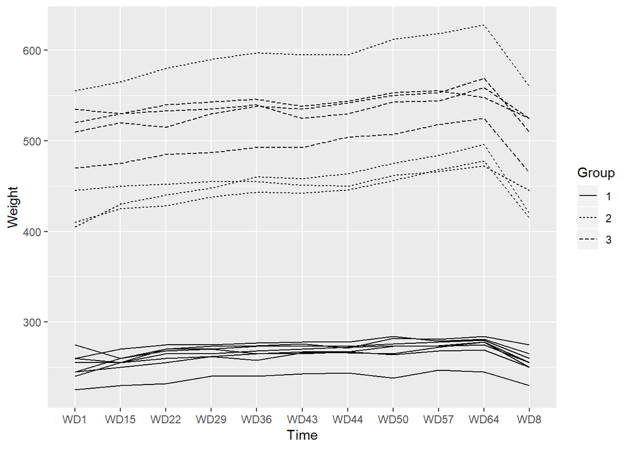

```r
ggplot(RATSL, aes(x = Time, y = Weight, group = ID, linetype = Group)) +
  geom_line()
```

Now here is a boxplot of the means of the weights of the different groups of mice:

```r
RATSL64 <- RATSL %>%
  filter(Time > 1) %>%
  group_by(Group, ID) %>%
  summarise(mean = mean(Weight)) %>%
  ungroup()
```

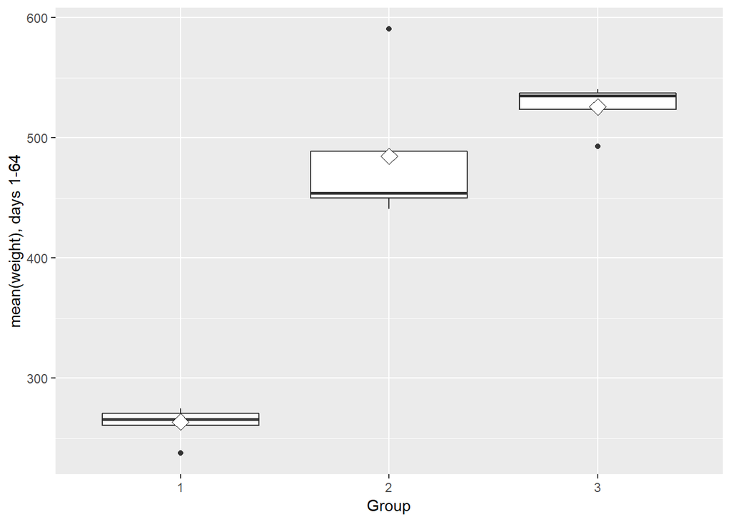

```r
ggplot(RATSL64, aes(x = Group, y = mean)) +
  geom_boxplot() +
  stat_summary(fun.y = "mean", geom = "point", shape=23, size=4, fill = "white") +
  scale_y_continuous(name = "mean(weight), days 1-64")
```

We can see that the mean is the lowest with the group one.

Then we want to show the same boxplots wihtout some outliers. This should give more accurate results.

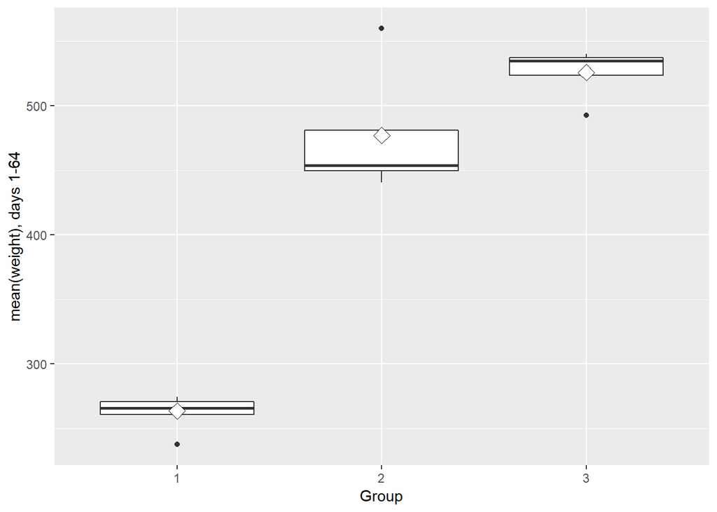

```r
RATSL641 <- RATSL %>%
  filter(Time > 1, Weight < 580) %>%
  group_by(Group, ID) %>%
  summarise(mean = mean(Weight)) %>%
  ungroup()

ggplot(RATSL641, aes(x = Group, y = mean)) +
  geom_boxplot() +
  stat_summary(fun.y = "mean", geom = "point", shape=23, size=4, fill = "white") +
  scale_y_continuous(name = "mean(weight), days 1-64")
```

Then we’ll move to analyze BPRS data. First we’ll make on boxplot to see how BPRS scores developed through the study period with each treatment

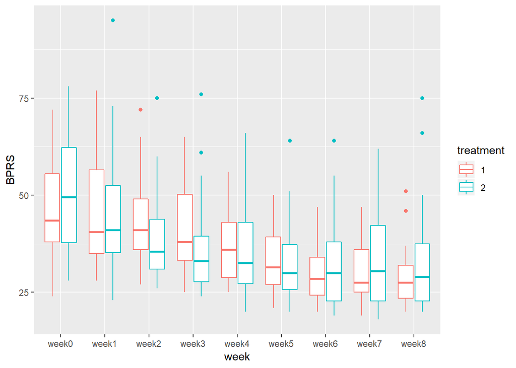

```r
ggplot(BPRSL, aes(x = week, y = BPRS, col=treatment)) +
  geom_boxplot()
```

Next we can see a linear model made to notice differencies between the two treatments:

```r
BPRS_reg <- lm(BPRSL$BPRS ~ BPRSL$treatment)
summary(BPRS_reg)
```

```
##
## Call:
## lm(formula = BPRSL$BPRS ~ BPRSL$treatment)
##
## Residuals:
##     Min      1Q  Median      3Q     Max
## -19.944 -10.372  -2.372   5.628  57.056
##
## Coefficients:
##                  Estimate Std. Error t value Pr(>|t|)
## (Intercept)       37.3722     1.0193  36.663   <2e-16 ***
## BPRSL$treatment2   0.5722     1.4416   0.397    0.692
## ---
## Signif. codes:  0 '***' 0.001 '**' 0.01 '*' 0.05 '.' 0.1 ' ' 1
##
## Residual standard error: 13.68 on 358 degrees of freedom
## Multiple R-squared:  0.0004399,  Adjusted R-squared:  -0.002352
## F-statistic: 0.1576 on 1 and 358 DF,  p-value: 0.6916
```

And here’s is a Random intercept model which allows more formal analysis of the data:

```r
library(lme4)
BPRSL_ref <- lmer(BPRS ~ treatment + (1 | subject), data = BPRSL, REML = FALSE)
summary(BPRSL_ref)
```

```
## Linear mixed model fit by maximum likelihood  ['lmerMod']
## Formula: BPRS ~ treatment + (1 | subject)
##    Data: BPRSL
##
##      AIC      BIC   logLik deviance df.resid
##   2848.5   2864.1  -1420.3   2840.5      356
##
## Scaled residuals:
##     Min      1Q  Median      3Q     Max
## -1.8055 -0.6981 -0.2207  0.5979  3.6280
##
## Random effects:
##  Groups   Name        Variance Std.Dev.
##  subject  (Intercept)  45.39    6.737
##  Residual             140.60   11.857
## Number of obs: 360, groups:  subject, 20
##
## Fixed effects:
##             Estimate Std. Error t value
## (Intercept)  37.3722     1.7466  21.398
## treatment2    0.5722     1.2499   0.458
##
## Correlation of Fixed Effects:
##            (Intr)
## treatment2 -0.358
```

Now we have taken a nice look to the data and made some very decent notions. Nice work!